# The Brexit Tuition Shock and the Price Elasticity of International Students

Evidence from a Natural Experiment

Stoycho Rusinov

James Rafiki Aketch

*Stoycho Rusinov, Center for the Study of Democracy, Sofia, and New Bulgarian University, Department of Informatics*  
*James Rafiki Aketch, School of Economics, University College Dublin*  
Correspondence to stoycho.rusinov@csd.eu

## Abstract

This paper estimates the price elasticity of EU demand for UK higher education using the Brexit-induced loss of Home Fee status and student-loan access as a quasi-experimental tuition shock. Unlike standard higher-education demand studies that rely on enrollment outcomes, the analysis uses UCAS application data, allowing demand to be observed before universities ration admissions. The mean country-specific post-Brexit treatment effect implies a change in applications of -67.0 percent, with elasticities varying substantially across the EU. Initial estimates suggest that applicants from lower-income member states were more price elastic, while wealthier countries experienced smaller demand contractions. However, once elasticities are rescaled using country-specific effective price shocks that account for the removal of income-contingent loans, the income gradient collapses and becomes statistically indistinguishable from zero. This indicates that much of the apparent cross-country heterogeneity reflects heterogeneous treatment intensity instead of stable differences in underlying preferences. The findings suggest that the UK student-loan system functioned as an important equalizing institution for European educational mobility, and that its removal transformed a nominally uniform tuition reform into a highly uneven economic shock across EU origin countries. The loan-adjusted elasticities are most strongly associated with the share of GDP allocated to education.

**JEL codes**: I22; I23; F22; J61; D12; C23

**Keywords:** Brexit; international student mobility; higher education demand; tuition fees; price elasticity; EU students; UCAS applications; difference-in-differences; synthetic control; income-contingent loans; educational mobility; heterogeneous treatment effects.

# 1 Introduction

International higher-education demand studies often struggle to isolate own-price elasticity because elasticity calculations usually rely on enrollment changes in response to price shifts. This approach is problematic because enrollment is an equilibrium outcome, shaped by both student preferences and capacity-constrained admission decisions (Hoxby, 1997; Bound et al., 2010). As a result, standard demand models using enrollment data conflate the desire to attend with the university's choice to admit.

In this paper, we assume that UCAS application data captures expressed demand before seats are rationed. Whether a student applies through the UCAS portal does not depend on how many places are available, as rationing occurs after applications are submitted. Our study uses cross-country variation, rather than traditional within-country, individual-level variation, to estimate international price responsiveness (i.e., demand elasticity).

To further clarify causal inference, we utilize the exogenous Brexit-induced tuition shock to estimate price elasticities at the origin-country level. The loss of Home Fee status and access to loans resulted from an external policy change, not a university pricing decision, creating a quasi-experimental setting for inferring willingness-to-pay. This causal design enables us to reconstruct country-specific, constant-elasticity demand functions for international applications around pre-Brexit price levels.

We show that under specific assumptions, applicants from lower-income EU countries exhibit highly elastic responses, significantly reducing their demand in response to the price hike. This heterogeneity implies that, while the UK higher education market faced a uniform regulatory shock, it also effectively filtered out price-sensitive consumers while retaining those with greater ability to pay. However, a more substantial contribution we make is that we later revisit these same elasticity estimates by adopting a different perspective on credit risk valuation prior to Brexit, showing that much of the observed demand heterogeneity is driven by the structure of the student loan system itself. This leads to the discovery that even though poorer EU economies initially exhibit very high demand elasticities, and demand elasticities strongly correlate with GDP per capita, when elasticities are rescaled using country-specific shocks from the value of the income-contingent loan, the income gradient shrinks to near zero, implying that most cross-country heterogeneity comes from treatment differences rather than preferences. The rescaled elasticity is more closely linked to the share of GDP invested in education than to GDP per capita itself.

# 2 Context

## 2.1 Brexit and higher education

Over the preceding decades, the UK higher education system has expanded under policies of widened access (Macdonald & Stratta, 2001; Brown, 2011). Although price elasticity in higher education is generally moderate (Hoxby, 1997), most studies focus on individual-level characteristics (Leslie, 2003), leaving macro-level effects less explored. Brexit was a multifaceted phenomenon that began as a political movement but ultimately led to the UK’s exit from the EU, which was described as a populist pushback against globalization and a shift away from “London” (Calhoun, 2017). One of its most significant outcomes, however, was the rupture of academic ties between the UK and the EU, with 2020 marking the final year that EU students paid domestic-level tuition; fees then doubled or tripled, making Brexit one of the largest tuition policy changes of the 21st century (Cuibus & Walsh, 2024; Mayhew, 2022).

This shift also reshaped student mobility, although a declining trend in UK students heading to Europe was noted as early as 2006 (Findlay et al., 2006), partly offset by increased flows to North America and Australia. Locke and Marini (2021) note that in the decade preceding the Referendum on the UK’s membership of the European Union (EU), there had been a rapid increase in foreign faculty in UK higher education institutions (HEIs), particularly from other EU countries. Many institutions had come to rely on academics from other EU countries, as well as those from outside the EU, for a significant part of their research, teaching, and other activities. Locke and Marini (2021) indicate that the growth in academic outflow to the UK (from 2004/2005 to 2017/2018) was most pronounced in countries such as Bulgaria, Croatia, Estonia, Latvia, and Lithuania. Luthra (2020) argues that the rejection of free movement created vulnerability among EU staff, highlighting feelings of insecurity regarding their legal rights and public acceptance within their workplaces.

The causal design of the Brexit shock was implemented later (once UCAS data became available). For example, Neville et al. (2024) document sharp post-2021 declines in EU applications and acceptances, even after controlling for COVID conditions. Clifton-Sprigg et al. (2025) explicitly conclude that the introduction of international tuition fees, rather than the referendum result or visa changes, caused the substantial contraction in EU study mobility. Our contribution advances these designs by treating the fee increase as a quasi-experimental price shock to identify origin-specific price elasticities from uncensored applications and by accounting for income-specific loan valuation. We therefore extend the literature by moving away from measuring how much demand fell to uncovering why it fell and what this implies for pricing and market structure.

## 2.2 Previous attempts to capture demand elasticities in higher education

Our use of DiD designs to recover structural demand parameters has a lineage in the IO literature, as Bresnahan (1982) showed that market-level price and quantity variation can identify demand elasticities when supply-side conduct is explicitly modeled. The present paper adapts this logic to a quasi-experimental setting, using the Brexit shock to identify the slope of country-level isoelastic demand curves. We extend the standard literature in the economics of education by building on Sá (2014), the closest methodological predecessor, who used the same UCAS application data and similar DiD logic to derive elasticities of 0.14–0.26 for domestic students. Her key finding is that credit-constrained students are not disproportionately affected, due to income-contingent loans equalizing access, a claim directly tested by Brexit, which removes those loans for an identifiable group. Our results extend the loan valuation mechanics by demonstrating that the income gradient in demand elasticities across EU countries collapses once elasticities are corrected for heterogeneous loan present values.

Endogeneity between demand and supply for higher education is another concern. Hoxby (1997) argues that increased competition in higher education can lead to higher tuition because institutions respond by differentiating their products, increasing quality, sorting students more sharply, and adjusting subsidies. In that account, rising tuition is an endogenous feature of a new competitive equilibrium. The Brexit design differs sharply in that the increase in tuition for EU students was not driven by institutional competition, quality upgrading, or a university-level pricing strategy. It was an externally imposed regulatory shock that removed Home Fee status and access to income-contingent loans while leaving the underlying educational product largely unchanged. This corresponds directly to Leslie and Brinkman (1987), who define demand elasticity as ε = (E/P), where E is the percentage change in enrollment, and P is the percentage change in price. If elasticity is derived from time-series variation rather than cross-sectional variation, then increasing competition can generate endogenous price shifts within the institutions affected.

Furthermore, Leslie and Brinkman (1987) explain that when we have a tuition elasticity from a time-series study, we cannot directly use it as a total-cost elasticity, because tuition and total cost did not move proportionally over time. This is why Brexit represents such an important empirical event, because it generated implicit tuition variation by sharply changing the effective price faced by EU applicants, allowing the analysis to identify how demand responds to changes in the actual cost of study rather than to nominal tuition alone. Campbell & Siegel (1967) present an example in which tuition rose 148% between 1927 and 1963, more than the total direct costs, so their tuition elasticity of −0.44 understates the true total cost elasticity.

Leslie and Brinkman (1987) further conclude that for every $100 increase in tuition price, given the 1982-83 average weighted higher education prices of $3,420 for tuition and room and board, one would expect a 18-24-year-old participation rate drop of about three-quarters of a percentage point. Since the national higher education participation rate was about 0.33 in 1982, U.S. enrollments would decline by about 2.1 percent for each $ 100 price increase, all other factors equal. This implies a price elasticity of about -0.73, which is largely consistent with some of our own estimates.

Savoca (1990) argues that standard enrollment-based estimates understate true demand sensitivity by conflating application behavior with admissions and matriculation decisions. Under the assumption that tuition and admissions policy are set independently, the price elasticity of enrollment equals the sum of the application and matriculation elasticities – a combined figure she estimates at −0.49, suggesting the true demand elasticity may be more than twice as large as conventional estimates. Following the modern wave of more robust causal evidence, Dwenger et al. (2012) corroborate this direction of effect in a different setting – among German high-school graduates, residing in a state with tuition fees reduces the probability of applying to a home-state university by 2 percentage points (against a baseline of 69%), with stronger responses among higher-achieving students.

To understand why the Brexit-derived elasticities may be larger than the standard estimates in the literature, consider, for example, Heller (1997), who argues that tuition increases reduce enrollment (so higher education is not a luxury good). The studies reviewed by Heller (1997) converge on the finding that each $100 tuition increase lowers enrollment by roughly 0.5 to 1.0 percentage points, which is consistent with Leslie and Brinkman (1987). Reductions in financial aid also reduce enrollment, though the effect varies by aid type. Lower-income students are more sensitive to changes in tuition and aid than middle- and upper-income students. The results presented in Hemelt and Marcotte (2011) are also relevant because they confirm the standard negative relationship between tuition and enrollment, but their design is also not directly comparable to Brexit.

Another branch in the literature is the **BLP-type models** (building on McFadden, 1974), which derive elasticities from estimated heterogeneity in preferences across differentiated alternatives; the present design derives elasticity from observed variation in exposure to a large policy-induced price shock. The former is better suited for recovering substitution matrices across choices; the latter is better suited for identifying a destination-level demand response to a discrete change in the relative price of UK higher education.

# 3 Data

The primary data source is the most recent release of the UCAS database (2025), covering application cycles from 2016 to 2025. UCAS provides centralized information on applications to UK higher education institutions, enabling us to observe applicant behavior before admissions decisions are made. This is particularly important for our empirical design, as applications capture expressed demand before institutional rationing takes place. The dataset reports application counts by country of domicile along with additional demographic breakdowns. In this study, application series are constructed by aggregating counts across all available categories of sex and gender to obtain total demand from each origin country, while country of domicile is retained as the key dimension of variation. A natural extension would be to derive gender-, age-, or subject-specific elasticities from the same data; we leave this for future work and focus here on aggregate flows due to space constraints.

The unit of observation is the origin-country–year, yielding a panel dataset that includes both EU countries (the treated group) and non-EU countries used to construct the “pseudo EU” (the artificial control group). The main outcome variable is the logarithm of the number of applications from country i in year t, which captures cross-country variation in demand over time. To analyze heterogeneity in responses to the Brexit-induced tuition shock, the UCAS data are merged with macroeconomic indicators, including GDP per capita and labor-market variables from the World Bank. The descriptive statistics are presented in Table 1.

**Table 1.** Descriptive statistics of the core variables in the analysis for both the treated and control groups. Statistics are computed on the 468 country-year World Bank estimation sample covering 52 countries from 2016 to 2024. Education spending as a share of GDP is available for 321 observations and does not restrict the estimation sample.

Descriptive statistics

| Variable | n | mean | sd | median | min | max |
| --- | --- | --- | --- | --- | --- | --- |
| Applicants | 468 | 1767.95 | 3745.32 | 715.00 | 35.00 | 33660.00 |
| log_app | 468 | 6.63 | 1.23 | 6.57 | 3.56 | 10.42 |
| EU | 468 | 0.50 | 0.50 | 0.50 | 0.00 | 1.00 |
| Post | 468 | 0.44 | 0.50 | 0.00 | 0.00 | 1.00 |
| did | 468 | 0.22 | 0.42 | 0.00 | 0.00 | 1.00 |
| event_time | 468 | 0.00 | 2.58 | 0.00 | -4.00 | 4.00 |
| regression_weight | 468 | 1.00 | 0.77 | 1.00 | 0.00 | 4.18 |
| GDPpc | 468 | 46483.36 | 26863.77 | 43093.45 | 2543.85 | 136772.44 |
| Pop15_65 | 468 | 42599339.26 | 138073627.78 | 6552301.50 | 305378.00 | 988168271.00 |
| YouthUnempl | 468 | 15.32 | 8.43 | 13.56 | 0.30 | 47.22 |
| EduSpendGDP | 321 | 4.59 | 1.43 | 4.59 | 0.38 | 8.74 |
| c_log_GDPpc | 468 | 0.00 | 0.78 | 0.15 | -2.68 | 1.30 |
| c_log_Pop15_65 | 468 | 0.00 | 1.73 | -0.22 | -3.28 | 4.80 |
| c_YouthUnempl | 468 | 0.00 | 8.43 | -1.75 | -15.02 | 31.91 |

Country-specific average wages *w<sub>j</sub>* are taken from Eurostat's *Average full-time adjusted salary per employee* indicator (*nama_10_fte*) for 2024 (Eurostat, 2025). The series reports gross annual salaries in current euros, harmonized across Member States by adjusting national-accounts wages with a full-time equivalent ratio from the EU Labour Force Survey. This wage enters the loan present-value calculation *PV<sub>loan</sub>(w<sub>j</sub>)* and determines the country-specific effective price shock *k<sub>j</sub>.* We use the 2024 wage because a student enrolling in 2021 would complete a standard three-year undergraduate cycle in 2024. The 2024 wage is therefore treated as the first post-graduation wage, and the simulated repayment schedule begins from that year.

Macroeconomic controls are drawn from the World Bank's World Development Indicators, accessed via the WDI R package (Arel-Bundock, 2022): GDP per capita in purchasing power parity terms, constant international dollars (NY.GDP.PCAP.PP.KD), working-age population aged 15–64 (SP.POP.1564.TO), and youth unemployment for ages 15–24 (SL.UEM.1524.ZS). Country codes were harmonised to ISO2 using the countrycode package (Arel-Bundock et al., 2018), and the series were merged with the UCAS panel on country–year. World Bank data are available through 2024 (World Bank, 2025). Since Lebanon was missing GDP per capita and “youth unemployment for ages 15–24” for 2024 we decided to use the arithmetic average from the previous two years to fill in those two values so the panel can be completely balanced.

It is also important to note that we use country-level data and not university-specific data (as in Sá (2014) or Clifton-Sprigg et al. (2025), for example) because of an internal limitation of the UCAS data itself. Once a student creates a registration in the UCAS web portal, they can choose up to 5 universities at once. Furthermore, the student can be accepted to all five of them. This results in double, and sometimes triple, counting of the same applicant. This internal limitation is absent when the series is country-level aggregated, because in this design, each applicant is counted only once per country.

# 4 Empirical strategy

## 4.1 Constructing the counterfactual European Union

The control group is constructed in two stages, with the full derivation reported in Online Appendix I. First, each origin country’s pre-treatment application path is converted into a standardized log-applicant trajectory for 2014–2020, using the historical UCAS extract that retains the years removed from the newest release. Starting after 2013 avoids contaminating the trajectories with Croatia’s accession to the EU. The main econometric panel is drawn independently from the newest UCAS extract and begins in 2016. We also limit the analytical sample to only those countries that maintain a consistent flow of at least 100 applications per annum. For every treated EU country, the three closest non-EU donor countries are then selected using Euclidean distance between standardized pre-treatment paths, so donor choice is based on trajectory shape and independent of market size.

Second, synthetic-control weights are estimated separately for each treated country over the pre-treatment period and then collapsed into a single global donor-weight vector used in the saturated DiD regressions. Treated observations receive unit weight, while donor weights are scaled so that the aggregate control mass equals the aggregate treated mass. This keeps the outcome in logged levels while using the donor pool only to construct a comparable weighted counterfactual. The full list of the “counterfactual” European Union, including the regression weights is presented on Table 2 below.

**Table 2.** Donor countries used to construct the synthetic counterfactual European Union, with global and regression weights.

Synthetic-control donor weights

| Donor country | Global weight | Regression weight |
| --- | --- | --- |
| Korea, Republic of | 0.161 | 4.178 |
| Trinidad and Tobago | 0.119 | 3.081 |
| Russian Federation | 0.108 | 2.803 |
| Malaysia | 0.097 | 2.530 |
| Mauritius | 0.079 | 2.066 |
| Egypt | 0.071 | 1.847 |
| New Zealand | 0.043 | 1.108 |
| United States of America | 0.042 | 1.102 |
| Qatar | 0.038 | 1.000 |
| Israel | 0.038 | 1.000 |
| Zimbabwe | 0.037 | 0.961 |
| United Arab Emirates | 0.036 | 0.923 |
| Indonesia | 0.031 | 0.796 |
| Mexico | 0.024 | 0.619 |
| Australia | 0.017 | 0.436 |
| Tanzania, United Republic of | 0.017 | 0.430 |
| China | 0.013 | 0.330 |
| Norway | 0.013 | 0.326 |
| Lebanon | 0.010 | 0.269 |
| Ireland | 0.008 | 0.197 |
| Switzerland | 0.000 | 0.000 |
| Turkey | 0.000 | 0.000 |
| Botswana | 0.000 | 0.000 |
| Iran, Islamic Republic of | 0.000 | 0.000 |
| Uganda | 0.000 | 0.000 |
| Brunei Darussalam | 0.000 | 0.000 |

## 4.2 Identification strategy and parallel trends

In a comparable perspective, the closest design to ours – Sá (2014) – exploits within-country, across-time variation in fees. The treatment in her case is binary and uniform: Scottish students either pay or don't, and English students face one fee level, then another. There is no cross-sectional variation in the size of the price shock. In this paper, however, we exploit cross-country, across-time variation, where the price shock itself, kⱼ, differs across countries because the present value of the foregone loan differs with the average wage. This means the identifying variation has two dimensions simultaneously – whether you are treated (EU vs. non-EU) and how intensely you are treated (which EU country you are from). This corrects an internal limitation in Sá's (2014) design, which cannot separately identify these because all treated students face the same fee change. This resonates with the fact that Sá's identification still relies on only 2 countries and 1 treatment switch, resulting in fewer effective independent treatment clusters.

Following these design choices, we estimate a dynamic difference-in-differences specification. This traces the evolution of applications around the Brexit tuition reform:

$$\log A_{it} = \alpha_i + \gamma_t +
\sum_{\ell \neq 0}\delta_\ell
\left(EU_i \times \mathbf{1}\{t-2020=\ell\}\right) + \varepsilon_{it}.
\tag{1}$$

The coefficients $\delta_{\mathcal{l}}$ measure those year-by-year deviations in log applications for EU-origin countries relative to the omitted pre-reform year ($\mathcal{l =}0$, corresponding to 2020). We, again, perform the regression with the weights supplied from the previous subsection.

**Figure 1.** Event-study estimates comparing EU applicants to the synthetic control group.

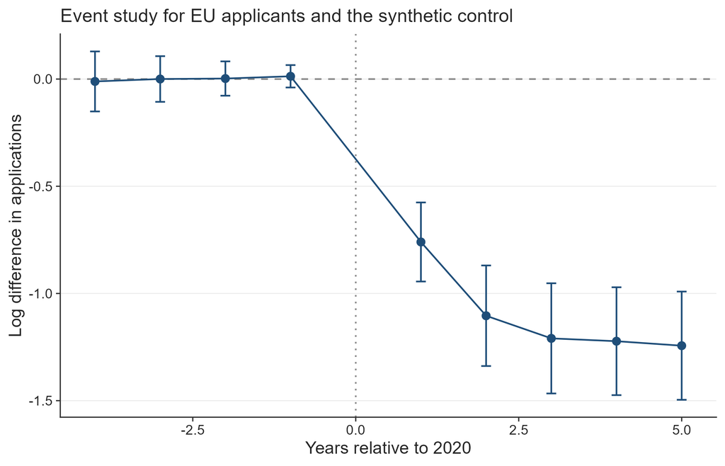

Note: The figure plots coefficients from a difference-in-differences event study comparing EU applicants with a synthetic control group of non-EU countries. The horizontal axis shows years relative to 2020, the last pre-treatment year. Points represent estimated differences in log applications and bars denote 95% confidence intervals clustered at the country level. A joint Wald test gives $p$ 0.959, providing no strong evidence of differential pre-trends.

Figure 1 reports the event-study coefficients from equation (1). The pre-treatment coefficients are very small and a joint Wald test fails to reject the null hypothesis that they are jointly equal to zero, with $p$ 0.959. No observable recovery is visible in 2024 and 2025, when pandemic disruption had largely abated. Due to a small positive divergence in post-referendum applications, there is also little indication that applications had already fallen because of migration concerns before the tuition reform.

**Figure 2.** Leads-only test without anticipation effects.

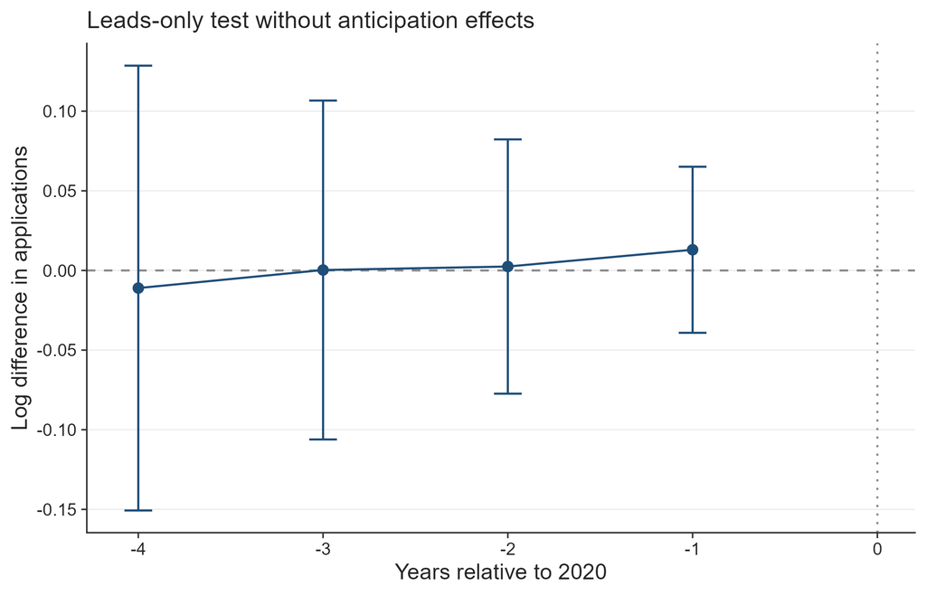

**Note:** The figure plots coefficients from a leads-only specification testing whether EU applications diverged from the synthetic control group before the Brexit tuition reform. Points represent estimated differences in log applications and bars denote 95% confidence intervals clustered at the country level. The estimates display no systematic pre-treatment pattern, and the joint Wald test gives $p$ 0.959.

To further assess identification, we implement two additional tests. First, a leads-only specification finds no evidence of anticipation effects, suggesting that applicants did not adjust behavior prior to the reform (Figure 2).

Finally, allowing for country-specific dynamic effects yields similar patterns: post-treatment coefficients are consistently negative across EU countries, while pre-treatment estimates remain close to zero (Figure 3). The only exception is Portugal, whose applications did not immediately collapse in 2021. This can be traced to a UCAS data reporting issue because in the 2021 cycle some Recorded Prior Acceptances (RPAs) were mistakenly submitted as domiciled in Portugal, so the true number of Portugal-domiciled RPAs is lower than the reported figure for that cycle (UCAS, 2022).

**Figure 3.** Saturated DiD event-study estimates by country.

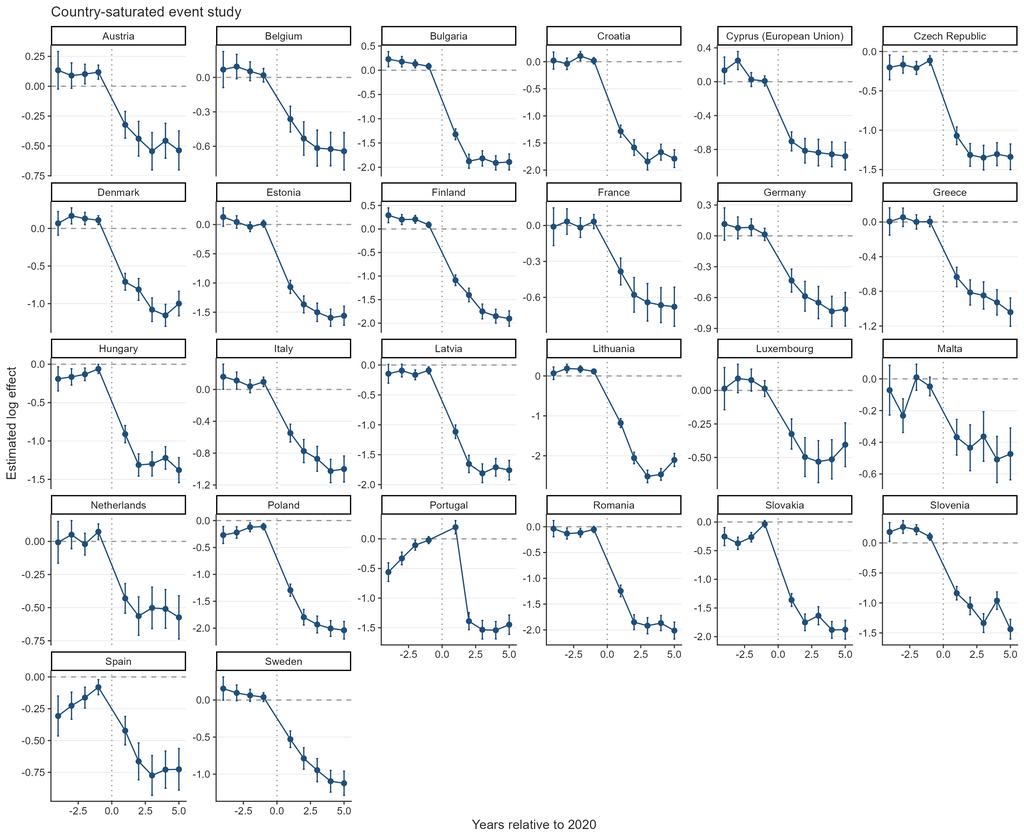

Note: Each panel reports country-specific dynamic treatment effects from the saturated difference-in-differences specification comparing EU countries with the pooled control group. Coefficients represent log differences in applications relative to the baseline year (2020). Error bars denote 95% confidence intervals. All results were completely replicated in Python and the output was the same.

## 4.3 Baseline elasticity estimates and the heterogeneous $k$

Let $\mathcal{C}$ denote the set of origin countries, partitioned into the treated EU markets $\Omega \subset \mathcal{C}$, with $J = |\Omega|$, and the candidate donor pool $\mathcal{D}=\mathcal{C}\setminus\Omega$ of non-EU markets. The empirical justification of the counterfactual European Union allows us to create a synthetic untreated group, enabling us to estimate the weighted saturated two-way DiD model:

$$\log A_{it} = \alpha_i + \gamma_t +
\sum_{j\in\Omega}\beta_j
\left(\mathbf{1}\{i=j\}\times Post_t\right)
+ \boldsymbol{\rho}'\mathbf{X}_{it} + \varepsilon_{it}.
\tag{2}$$

where $A_{it}$ denotes applications from origin country $i \in \mathcal{C}$ in year $t \in [2016,2025]$, $\mathbf{1}\{i=j\}$ identifies each EU member state, and $Post_t$ marks the introduction of the new tuition regime in 2021. The interaction coefficient $\beta_j$ captures the country-specific change in applications relative to the synthetic EU.

To distinguish between short-run and persistent effects, we further split the post-treatment period into two phases: 2021–2023, which captures the immediate response following the reform, and 2024 onward, which reflects longer-run adjustments. The specification becomes:

$$\begin{aligned}
\log A_{it} ={}& \alpha_i + \gamma_t
+ \sum_{j\in\Omega}\beta_j
\left(\mathbf{1}\{i=j\}\times PostBrexit_t\right) \\
&+ \sum_{j\in\Omega}\sigma_j
\left(\mathbf{1}\{i=j\}\times PostCovid_t\right)
+ \boldsymbol{\rho}'\mathbf{X}_{it} + \varepsilon_{it}.
\end{aligned}
\tag{3}$$

from here follows the interpretation of $\beta_{j}\$ as the short-run country specific response (Brexit + COVID uncertainty) and${\ \sigma}_{j^{\ }}$ is the persistent structural response (pure willingness-to-pay shift). The difference $\beta_{j} - \sigma_{j^{\ }} = \omega_{j}$ provides the specific COVID impact on demand elasticities (mathematical proof for this in the supplementary materials).

We show in the supplementary materials that the $\beta_{j},$ with $j \in \Omega$, coefficient can be mapped to a structural elasticity parameter through the following transformation (Bresnahan (1982) style):

$\eta_{j} = \frac{\beta_{j}}{k_{j}}$,

Where $\eta_{j}$ is the price elasticity (with expected negative sign due to the negative slope of the demand curve). To allow heterogeneous $k$’s, under the Plan 2 for the contingent student loan, graduates had to repay 9% of annual earnings above a statutory repayment threshold (UK Government, n.d.-a). For the relevant cohort, the repayment threshold is £27,295 per annum. Annual repayments are therefore defined as $R_{t} = 0.09 \cdot \max{\{ 0,Y_{t} - \tau\}}$ in which τ denotes the repayment threshold and *Y*<sub>t</sub> follows a deterministic wage path with annual growth rate g. The loan is written off 30 years after the April in which repayment becomes due (UK Government, n.d.-b), implying a finite repayment horizon T=30 years. Interest accrues at the Retail Price Index (RPI) plus up to three percentage points, depending on income (UK Government, n.d.-c). Instead of replicating the full income-dependent interest schedule, we model the economic burden of the loan as the present value of expected repayments and discount repayment flows at a constant rate δ. The present value of the loan is therefore defined as:

$$p_{jt}=\min\left\{
0.09\max\left[0,w_j^{GBP}(1+g)^{t-1}-\tau\right],
\left[L-\sum_{s=1}^{t-1}p_{js}\right]_+
\right\}.$$

$$PV_{loan}\left( w_{j}^{GBP} \right) =
\max\left\{ 1,\ \sum_{t = 1}^{30}\frac{p_{jt}}{(1 + \delta)^{t}}
\right\}$$

where $L=\text{£}9{,}250$ and $[x]_+=\max\{x,0\}$. In the baseline specification, we set $\delta=3\%$ and $g=2\%$. The maximum operator ensures that the logarithmic transformation remains defined even when the present value is zero. Annual nominal wage growth is anchored to the ECB’s symmetric 2% medium-term inflation target (European Central Bank, 2021).

We estimate the present value based on the average country specific wage ($w_{j}^{GBP})$ and $k$ becomes a function of the average wage:

$$k_{j} = \log 22200 -
\log{PV_{loan}(w_{j}^{GBP})}$$

in this formula $PV_{loan}(w_{j}^{GBP})$ is the present value of the income contingent UK loan, £22,200 is the average post-Brexit price and $w_{j}$ is the average annual salary in pounds (for 2024, converted from euros at an exchange rate of 0.85). https://www.exchangerates.org.uk/EUR-GBP-spot-exchange-rates-history-2024.html

Intuitively, the calculation can be read from the perspective of a student graduating in 2024. The student asks how much they would actually repay under the old income-contingent loan system, given their expected first post-graduation wage. We therefore use the 2024 wage as the starting point, project it forward over 30 years, calculate annual repayments under the loan rule, and discount those future repayments back to 2024. This gives the effective price of the old regime. Upon peer-review objections, we would like to mention that discounting the £22,200 price would be inappropriate in this setup because it would reclassify a current tuition obligation as if it were a deferred income-contingent repayment stream. The asymmetry is therefore institutional and not arbitrary. The old price is mediated through a future repayment contract, whereas the new price is a direct posted fee.

This step of discounting here is crucial because under the standard shift from 9250 pounds and no heterogeneity assumption $k$ is 0.875. Clifton-Sprigg (2025) assumes one unique price change (from the old price of 9250 to 22200) but the above equation allows us to relax this assumption. This extension is especially relevant in light of Solís’s (2017) findings that credit access leads to a 100 percent increase in immediate college enrollment and a 50 percent increase in the probability of ever enrolling.

We then relate these elasticities to observable economic fundamentals. Specifically, we estimate correlations of the form:

$$\frac{\beta_j}{k_j} = \theta_0 + \gamma\log(GDPpc_j)
+ \mathbf{X}_j'\boldsymbol{\rho} + u_j.
\tag{4}$$

Where $\rho^{'}X$ is a list of country specific covariates that control for structural characteristics at the country level. This exercise documents that income strongly predicts the magnitude of the shock, consistent with a segmented higher-education market in which price sensitivity varies systematically with economic fundamentals.

# 5 Results

## 5.1 Estimated baseline elasticities

Following the empirical strategy, Figure 4 reports country-specific elasticities derived from the difference-in-differences estimates. We translate the estimated treatment effects into implied demand responses to the Brexit tuition shock.

**Figure 4.** Decomposition of the post-Brexit demand elasticities by treated country.

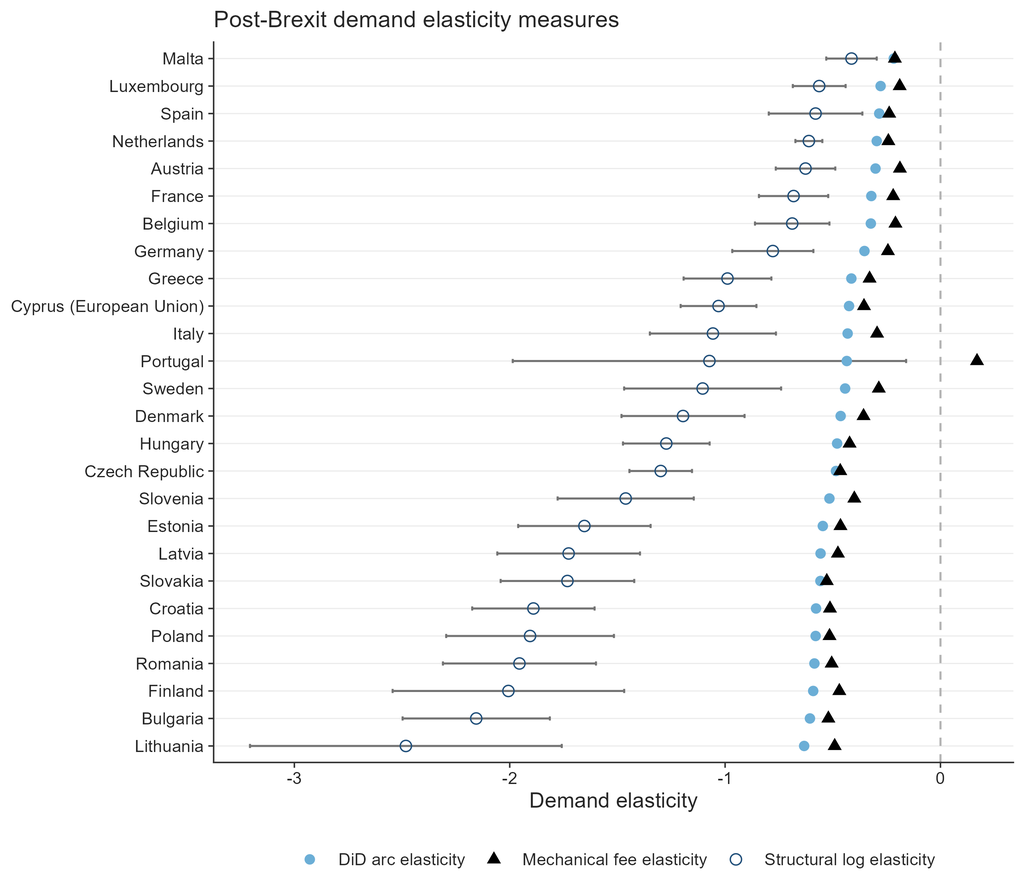

Note: The structural log elasticities are obtained from the division of the country-specific effect ($\beta_{j})$ by 0.875. The Arc elasticities are obtained by $\left( e^{\beta} - 1 \right)/1.4$ and the mechanical arc elasticities by $\Delta Applications_{2020}^{2021}/1.40$. The transformation of $e^{\beta} - 1$ is valid only if the software is using logarithmic transformations in natural logarithms. Since R uses natural logarithms as default this transformation is safe. Used are Driscoll-Kraay (L=1) standard errors consistently and across all the presented models. Details in the online appendix.

The results indicate a large and widespread contraction in demand. The mean country-specific coefficient implies a change of -67.0%. All DiD elasticities lie below zero, confirming a contraction in EU demand for UK higher education. The magnitude varies substantially across origin countries. Wealthier EU countries such as Malta, Spain, Luxembourg, the Netherlands, and Austria have comparatively smaller elasticities, while Bulgaria, Romania, Lithuania, Croatia, and Latvia show much larger unadjusted responses. We later show why interpreting this pattern as stable preference heterogeneity is misleading.

This heterogeneity also aligns closely with cross-country differences in income. Regressing the estimated country-specific responses on GDP per capita reveals a strong positive relationship where wealthier countries experience smaller declines in applications (Figure 5). The strong positive relationship between GDP per capita and demand elasticity emerges only when elasticities are estimated using fixed effects specifications. This reflects the ability of the TWFE estimator to isolate the causal impact of the Brexit-induced tuition shock by removing both country-specific baseline differences and common time shocks. In contrast, pooled estimates conflate treatment effects with cross-country heterogeneity in levels and trends, obscuring the underlying relationship. As a result, the GDP gradient disappears when identification is not enforced. Furthermore, even when the elasticities are estimated with additional controls, included in the saturated DiD regression, the correlation with GDP per capita remains strong. This correlation appears to weaken only once $k_{j}$ ($\delta = 3\%$ and $g = 2\%$) is assumed heterogeneous and dependent on the income contingent loans the EU students were previously exposed to. The direction of the previously positive gradient loses significance once *k* is made heterogeneous. In the fixed-effects models this positive gradient loses significance after the loan adjustment, while in the pooled loan-adjusted specification the relationship reverses and turns significantly negative, which shows how much the pattern depends on controlling for persistent country heterogeneity (Figure 5).

**Figure 5**. Correlations between the DiD (FEs and No FEs elasticities) and logarithm of GDP per capita

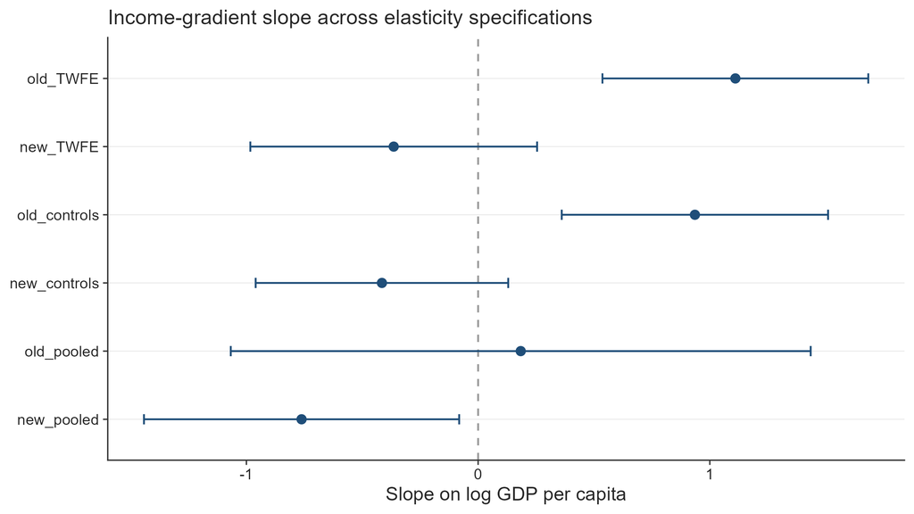

An important consideration is that the tuition reform altered not only nominal prices but also the availability of income-contingent loans. The baseline elasticity estimates, however, rest on the assumption that the Brexit reform generated a uniform effective price change across EU countries. We argue in the discussion section that this assumption is unlikely to hold, and that once it is relaxed, the cross-country pattern changes substantially. Details on the construction of elasticity measures and alternative definitions are provided in Appendix A.

## 5.2 Estimated COVID-specific elasticities

**Figure 6** compares the immediate post-Brexit demand elasticities with the persistent elasticities observed after pandemic disruptions had abated. The difference between the dots is consistent with the effect derived in the supplementary materials.

**Figure 6.** Post-Brexit and post-COVID demand elasticities compared on the same measurement axis.

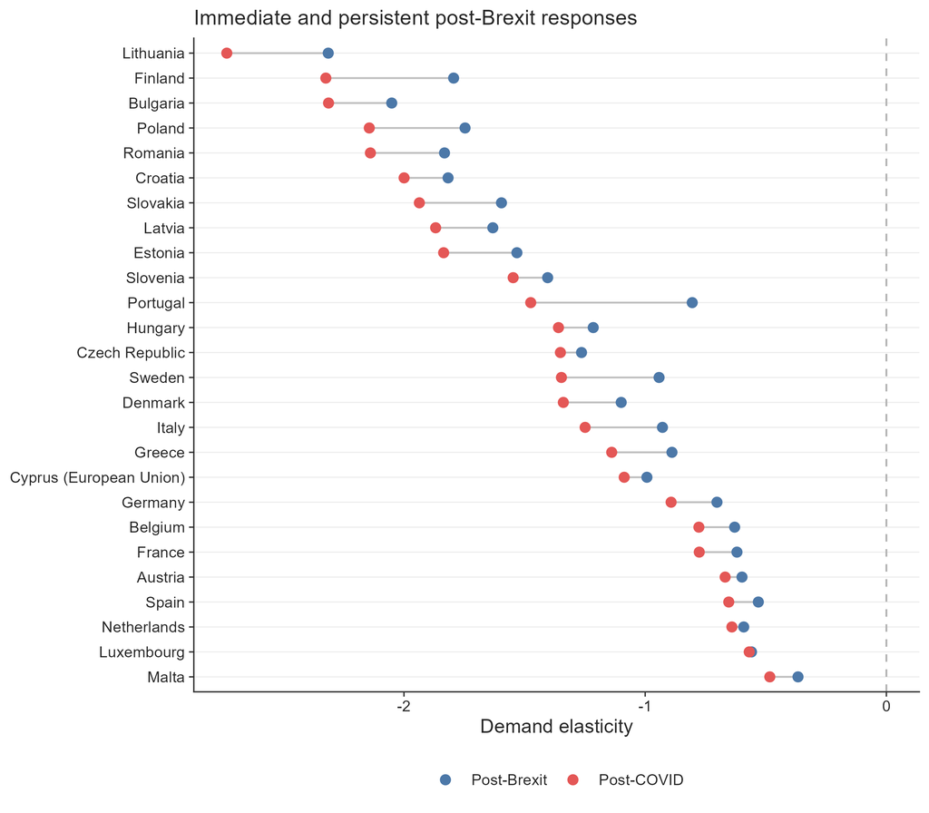

Note: Used are the naïve elasticities across all the models. The COVID coefficients are coded for the period 2021-2023, while 2024 to 2025 are assumed to be only the persistency effects of the Brexit tuition regime. Used are Driscoll-Kraay (L=1) standard errors consistently and across all the presented models. Details in the online appendix.

It is also important to mention that for nearly all EU origin countries, the persistent post-COVID elasticities remain strongly negative and closely aligned with the initial post-2021 estimates. The persistence of the elasticities confirms that price sensitivity, rather than short-run volatility, is the dominant mechanism behind the observed demand contraction.

For nearly all EU origin countries, the persistent 2024 to 2025 effects are at least as negative as the immediate 2021 to 2023 effects, so there is little sign of recovery once the COVID window passes. The absence of recovery is especially pronounced among lower-income countries, although the deepening contraction is visible throughout much of the income distribution.

## 5.3 ATT wealth heterogeneity

**Table 3.** ATE coefficient and interactions. FEs are always entity and time. Standard errors are Driscoll & Kraay (1998) (L=1)

Pooled TWFE models with macroeconomic controls

|  | robustness$cont..1 \|robustness$cont..2 | robustness$contr..4 \|robustness$contr..5 | robustness$cont..6 |  |  |
| --- | --- | --- | --- | --- | --- |
|  | I | II | III | IV | V |
| Dependent Var.: | log_app | log_app | log_app | log_app | log_app |
| ATT | -1.109*** (0.0983) | -1.049*** (0.1105) | -0.9801*** (0.1008) | -0.9605*** (0.0917) | -1.210*** (0.1195) |
| Centered log GDP per capita |  | -0.7358* (0.2606) | -0.4611 (0.2606) | -0.7028* (0.2845) | 0.0017 (0.2975) |
| Centered log working-age population |  |  | 3.073*** (0.4605) | 3.209*** (0.5205) | 2.629*** (0.4621) |
| Centered youth unemployment |  |  |  | -0.0141* (0.0045) | -0.0083+ (0.0040) |
| ATT × centered log GDP per capita |  |  |  |  | 0.8088*** (0.1365) |
| ATT × centered log working-age population |  |  |  |  | 0.1001*** (0.0130) |
| ATT × centered youth unemployment |  |  |  |  | 0.0108 (0.0060) |
| Fixed-Effects: | —————— | —————— | ——————- | ——————- | —————— |
| Domicile_named_country | Yes | Yes | Yes | Yes | Yes |
| Year | Yes | Yes | Yes | Yes | Yes |
| ________________________________________ | __________________ | __________________ | ___________________ | ___________________ | __________________ |
| S.E. type | Drisco.-Kra. (L=1) | Drisco.-Kra. (L=1) | Driscoll-Kra. (L=1) | Driscoll-Kra. (L=1) | Drisco.-Kra. (L=1) |
| Observations | 520 | 468 | 468 | 468 | 468 |
| Adj. R2 | 0.95672 | 0.95787 | 0.96365 | 0.96445 | 0.96993 |
| Within R2 | 0.58513 | 0.58618 | 0.64381 | 0.65253 | 0.70830 |

**Note:** Models (I) through (V) are estimated with the standard TWFE estimator. Model (I) uses the full panel of 520 observations, while specifications with World Bank controls use 468 observations because the PPP GDP series carries no 2025 value. The centered variables subtract the full-sample mean, $\log(x_i)-\overline{\log(x_i)}$, before estimation. All models use Driscoll-Kraay standard errors with one lag. Significance is marked as + $p<0.1$, * $p<0.05$, ** $p<0.01$, and *** $p<0.001$. GDP per capita is measured in purchasing-power-parity terms at constant international prices.

Table 3 reports regressions that relate the magnitude of the Brexit demand shock to country-level economic characteristics. Across all specifications, the baseline effect remains large, negative, and statistically significant, confirming a substantial contraction in EU demand following the tuition reform. At the same time, there is clear evidence of heterogeneity. The interaction between the Brexit treatment and GDP per capita is positive and statistically significant, indicating that higher-income countries experience smaller declines in applications. This is consistent with lower price sensitivity in wealthier contexts.

Working-age population also plays an important role. The interaction with population is positive and precisely estimated, indicating that the contraction was further attenuated in demographically larger origin countries, where UK higher education is one option among a broader domestic and international set. By contrast, the interaction with youth unemployment is positive but statistically indistinguishable from zero in the fully interacted specification, so weaker youth labour markets do not measurably change the response to the fee shock.

**Figure 7.** Saturated DiD specifications with macroeconomic controls added. Namely GDP per capita (PPP, constant prices), population and the percentage of youth unemployment as separate models.

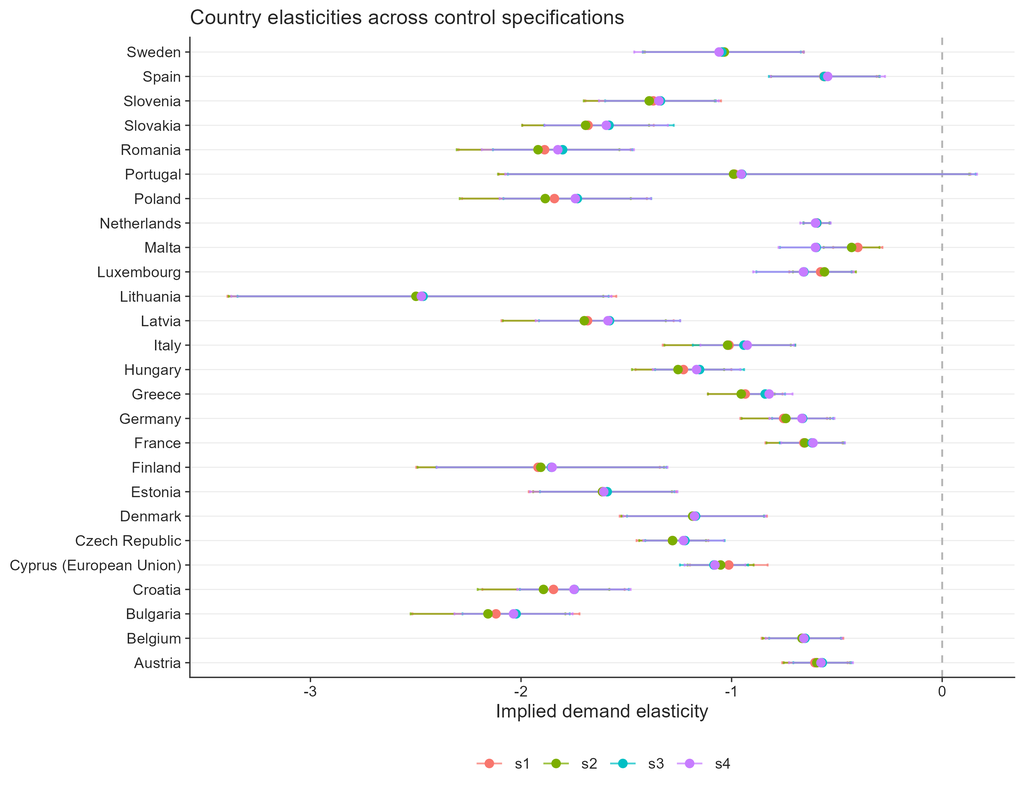

**Note:** All saturated models use the demeaned version of the free covariates – namely, the GDP per capita, the population and the youth unemployment. Used are Driscoll-Kraay (L=1) standard errors consistently and across all the presented models. Details in the online appendix.

# 6 Robustness

## 6.1 Control-group robustness

We assess the robustness of the baseline results mainly against the choice of the control group. This is because previous work has already confirmed that (Clifton-Sprigg et al. (2025)):

1. The Brexit shock was indeed a valid quasi-experiment with stable pre-trends
2. There were no anticipation effects and no major spillovers from the Brexit referendum in 2016
3. Clifton-Sprigg even performed a robustness exercise by using the Croatian case that in itself created quasi-experimental evidence when the country joined the Union.

What remains is to ensure that the result is not dependent on the choice of the control group and that, regardless of its construction, we should not expect grossly different results on average. To achieve that goal, we construct four alternative control groups to our own, namely very poor countries (14 in total), very rich countries (13 in total), only OECD countries (14 in total), and Ireland as a single-country comparison. The three multi-country compositions are described in further detail in Table 4.

**Table 4.** Sample compositions for the alternative control groups

Alternative control-group samples

| Control group | Countries | EU countries | Observations |
| --- | --- | --- | --- |
| Poor | Pakistan, Nepal, Bangladesh, Ethiopia, Uganda, Tanzania, United Republic of, Rwanda, Mozambique, Malawi, Sierra Leone, Ghana, Nigeria, Kenya, Zimbabwe | 26 | 400 |
| Rich | United States of America, Canada, Australia, Norway, Switzerland, Singapore, Qatar, United Arab Emirates, Kuwait, Saudi Arabia, Israel, Japan, Hong Kong | 26 | 390 |
| OECD | Australia, Canada, Chile, Colombia, Iceland, Israel, Japan, Korea, Republic of, Mexico, New Zealand, Norway, Switzerland, Turkey, United States of America | 26 | 400 |

Note: To avoid the proliferation of too many tables detailed statistical description of the used groups is provided in the supplementary materials section.

Since under this new design the construction of the control group is not based on constrained optimization we use the following formula for the weighting of the counterfactual:

$$w_{j} = \frac{\frac{1}{d_{j} +
0.001}}{\frac{1}{J}\sum_{k = 1}^{J}\frac{1}{d_{k} + 0.001}}$$

where $d_{j} = \sqrt{\frac{1}{T}{\sum_{t < 2021}^{\ }\left( \log\left( A_{jt} \right) - \overline{\log\left( A_{t}^{EU} \right)} \right)}^{2}}$. The results are presented in Figures 8 and 9 for the ATT and the country-specific responses, respectively.

**Figure 8.** Robustness of the Brexit effect across alternative control-group definitions (pooled DiD estimates).

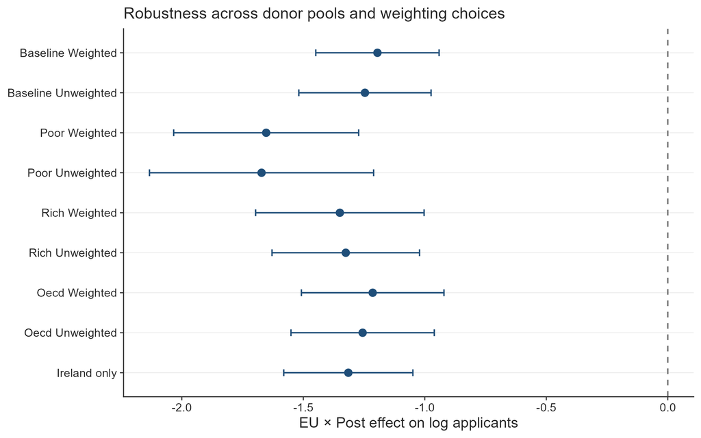

**Note:** Points are EU × Post coefficients from the pooled difference-in-differences specification; horizontal bars denote 95% confidence intervals. Baseline is the synthetic donor pool used in the main specification; Poor, Rich, and OECD are the alternative control groups described in Table 4, each shown weighted and unweighted; Ireland is a single-country comparison.

**Figure 9.** Saturated difference-in-differences robustness across control-group specifications.

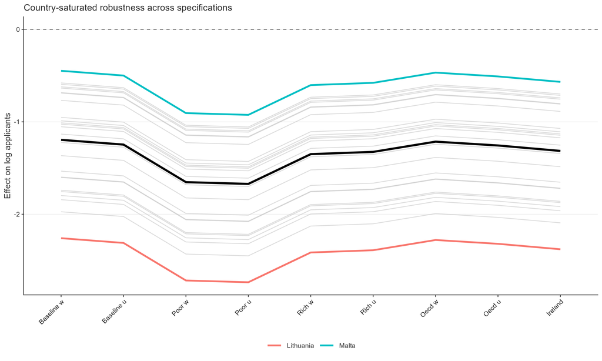

The robustness exercises on Figures 8 and 9 show that the estimated Brexit effect is not an artifact of a particular donor-pool construction. Across all alternative control groups, the coefficient on EU × Post remains large, negative, and far from zero. Whether the control group is built from the baseline synthetic donor pool, OECD countries, high-income countries, low-income countries, or Ireland alone, the estimated collapse in EU applications remains of similar order of magnitude. The point estimates move because each donor pool implies a different untreated benchmark, but none of the alternative specifications changes the substantive conclusion.

The poor-country control group generates the most negative estimates. This is informative because it shows that the decline is not a generic post-pandemic fall in applications from low-income origins. If that were the mechanism, low-income non-EU countries should absorb much of the EU decline and push the coefficient toward zero. The Ireland-only specification is also useful as a diagnostic. Ireland is deeply connected to the UK higher-education market through language, proximity, and institutional familiarity, so it provides a demanding comparison. It is also the only EU country not affected by the shift in tuition status. If the result were driven by common shocks to nearby or culturally connected markets, the comparison with Ireland should substantially weaken the estimate. It does not. The estimate remains close to the other robustness results, reinforcing the interpretation that the post-2021 break reflects the EU-specific loss of Home Fee status and loan access. Figure 9 also strengthens the robustness of the main results by showing that the ranking of the post-Brexit responses is preserved regardless of the chosen baseline. Another important point is that weighting affects the final estimates only at the margin. As a further check that does not rely on the constrained donor weights, we estimate the average treatment effect on the full donor pool with the standalone synthetic difference-in-differences estimator of Arkhangelsky et al. (2021). The estimator returns an ATT of -1.23 with a jackknife standard error of 0.10 and a 95% confidence interval from -1.43 to -1.02. This falls squarely within the range of the pooled and saturated estimates reported above and confirms that the headline collapse in EU applications does not hinge on how the counterfactual is weighted.

## 6.2 $k_j$ robustness

A natural objection to the loan correction is mechanical. Because the loan-adjusted price change $k_{j}$ falls with income, dividing the estimated effect ${\widehat{\beta}}_{j}$ by $k_{j}$ will attenuate any income gradient almost automatically, so the collapse of the gradient could reflect nothing more than division by an income-correlated quantity and not necessarily the economic content of the loan. To separate these, we construct a placebo denominator that carries the income dependence of $k_{j}$ but none of its structure. We take log wages as a pure monotone income signal, with no repayment threshold, no finite horizon, and no discounting, and rescale it by a min-max transformation onto the exact range spanned by the real $k_{j}$. Writing the rescaling explicitly:

$$k_j^{placebo}=
\frac{\log w_j-\min_i(\log w_i)}{\max_i(\log w_i)-\min_i(\log w_i)}
\left(\max_i k_i-\min_i k_i\right)+\min_i k_i.$$

By construction, $k_{j}^{placebo}$ spans the identical interval to $k_{j}$, with its minimum and maximum pinned to $\min k_{i}$ and $\max k_{i}\$, so the two denominators differ only in how they map income onto that interval and not in scale. The real $k_{j}$ bends through the present value of the income-contingent loan, saturating at higher incomes as graduates repay the full principal, whereas $k_{j}^{placebo}$ rises monotonically in log income without saturating. We then form placebo elasticities ${\widehat{\beta}}_{j}$ divided by $k_{j}^{placebo}$ and re-estimate the income gradient.

The results isolate the loan mechanism. Under a common price change the gradient is 1.11 with $p$ < 0.001. Under the real loan-adjusted $k_j$ it changes to -0.36 with $p$ 0.236, and its confidence interval spans zero. Under the placebo income-only denominator, rescaled to the same range, the gradient is 0.87 with $p$ 0.038. All three models use 25 countries. A monotone income divisor therefore does not reproduce the collapse. What dissolves the income gradient is specifically the curvature the income-contingent loan imposes on the effective price change, particularly its saturation at higher expected earnings. This is direct evidence that the loan-valuation channel drives the disappearance of the income gradient.

Another criticism faced during peer review is the sensitivity of the present value calculation to changes in the calibrated parameters. To address this, we recompute the present values and reestimate the correlations with the following loan-correction mechanisms. This is shown in Figure 10. Across the discount-rate sweep the loan-adjusted income gradient stays statistically insignificant throughout, with its p-value sitting above the 5% line at every calibration. The wage-growth sweep is more nuanced. The gradient is significant only at the two lowest calibrations, g = 0 (p ≈ 0.04) and g = 0.5% (p ≈ 0.05), and becomes statistically insignificant from g = 1% onward. The underlying slope moves across the sweep as well, running from about -0.722 at a growth rate of 0% to about 0.291 at 4% as it reverses sign, while the standard errors stay largely unchanged. The disappearance of the income gradient therefore holds across the discount-rate sweep and across the baseline and most plausible positive wage-growth calibrations, though not across the entire parameter space.

**Figure 10.** Sensitivity of the loan-corrected income gradient to the discount rate and wage growth rate assumptions.

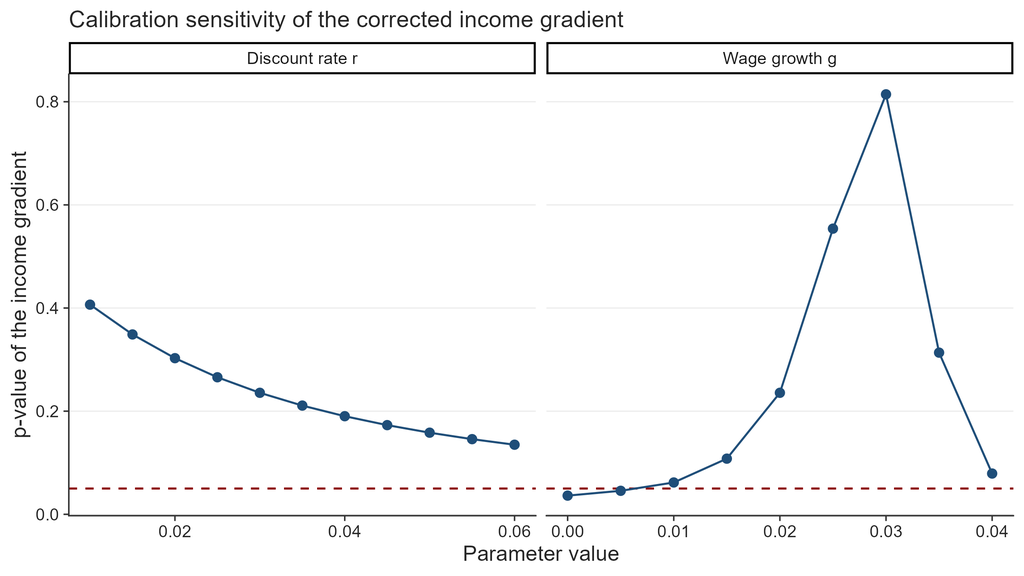

**Note:** The figure plots the p-value of the income gradient, that is the slope of the loan-corrected elasticity on log GDP per capita (PPP) as the discount rate (δ) and the annual wage growth rate (g) are varied around their baseline calibration (δ = 3%, g = 2%), holding all other parameters at the values described in the main text. GDP per capita is in PPP terms (constant international dollars) with data from 2022. The dashed line marks the 5% significance level, so points above it indicate calibrations where the income gradient is not statistically significant.

## 6.3 Rambachan-Roth parallel-trends checks and synthetic difference-in-differences comparison

In response to a further round of peer review we run two additional robustness checks. The first re-examines the parallel-trends assumption behind the event study using the HonestDiD implementation of the sensitivity analysis of Rambachan and Roth (2023), which replaces the binary test of whether pre-trends are flat with a measure of how large a post-treatment violation of parallel trends would have to be before the estimated effect loses significance. Because the pre-treatment leads are jointly indistinguishable from zero and are about two orders of magnitude smaller than the post-treatment coefficients, the loan-driven collapse in EU applications survives the relative-magnitudes sensitivity analysis across the full range of violations examined. The robust confidence set for the first post-treatment year never crosses zero, running from −0.94 to −0.58 when no violation is permitted, from −0.95 to −0.56 when the post-period distortion is allowed to be as large as the worst pre-period deviation, and from −0.98 to −0.53 at twice that size. The breakdown value therefore exceeds two, so the result is not an artifact of an assumed pre-trend (Roth, 2022).

The second check re-estimates 26 separate synthetic difference-in-differences regressions, one for each treated country, to demonstrate the robustness of the estimator. In this specification the Arkhangelsky et al. (2021) estimator collapses to $N_{tr} = 1$:

$${\widehat{\tau}}_{j}^{sdid} = \left(
{\overline{Y}}_{j,post} - \sum_{t \leq T_{0}}^{\ }\lambda_{t}^{j}Y_{jt}
\right) - \sum_{i \in D}^{}\widehat{\omega_{i}^{j}}\left(
{\overline{Y}}_{i,\ post} - \sum_{t \leq T_{0}}^{\
}\lambda_{t}^{j}Y_{it} \right)$$

**Table 5.** Per-country saturated DiD (TWFE) and synthetic difference-in-differences estimates

Country-level estimator comparison

| Country | Saturated TWFE | Synthetic DiD | Difference |
| --- | --- | --- | --- |
| Lithuania | -2.173 | -2.204 | 0.031 |
| Bulgaria | -1.887 | -1.877 | -0.011 |
| Finland | -1.756 | -1.722 | -0.034 |
| Romania | -1.711 | -1.884 | 0.172 |
| Poland | -1.668 | -1.949 | 0.281 |
| Croatia | -1.655 | -1.769 | 0.114 |
| Slovakia | -1.516 | -1.851 | 0.335 |
| Latvia | -1.512 | -1.716 | 0.205 |
| Estonia | -1.447 | -1.505 | 0.057 |
| Slovenia | -1.280 | -1.251 | -0.029 |
| Czech Republic | -1.137 | -1.388 | 0.251 |
| Hungary | -1.114 | -1.352 | 0.238 |
| Denmark | -1.046 | -1.086 | 0.040 |
| Sweden | -0.967 | -0.999 | 0.032 |
| Portugal | -0.939 | -1.353 | 0.414 |
| Italy | -0.925 | -0.948 | 0.023 |
| Cyprus (European Union) | -0.902 | -0.907 | 0.005 |
| Greece | -0.866 | -0.964 | 0.098 |
| Germany | -0.681 | -0.731 | 0.050 |
| Belgium | -0.603 | -0.665 | 0.062 |
| France | -0.597 | -0.708 | 0.111 |
| Austria | -0.549 | -0.588 | 0.040 |
| Netherlands | -0.535 | -0.641 | 0.106 |
| Spain | -0.508 | -0.808 | 0.300 |
| Luxembourg | -0.493 | -0.572 | 0.079 |
| Malta | -0.362 | -0.570 | 0.208 |

Note: Coefficients are on the log-applicant scale. Saturated TWFE effects are country-specific EU × Post coefficients from the weighted saturated difference-in-differences model using 520 country-year observations. Synthetic DiD effects are 26 separate single-treated-unit estimates, each identified against the full non-EU donor pool. The two sets of estimates correlate at 0.97, with a mean absolute difference of 0.13 log points.

# 7 Discussion

## 7.1 Were poor EU students really priced out because of elastic demand?

A natural interpretation of the results is that students from lower-income EU countries exhibit more elastic demand for UK higher education. However, this interpretation relies on the assumption that the tuition reform generated the same effective price change across countries. In practice, this assumption is unlikely to hold. Prior to Brexit, tuition was financed through income-contingent loans, meaning that the relevant economic price depended on expected future earnings rather than the nominal fee. As a result, the removal of these loans likely generated larger effective price increases for applicants from lower-income countries.

To illustrate how elasticities depend on loan valuation, we compute implied elasticities using the estimated average treatment effect, $\beta = -1.109$, and map it across a range of starting income levels in Figure 11. When the loan is expected to have a low present value, the Brexit reform constitutes a large effective price shock and the implied elasticity is smaller in magnitude. Conversely, when the loan’s present value approaches its nominal amount, the effective price shock is smaller and the implied elasticity is larger in magnitude.

**Figure 11.** Implied demand elasticity as a function of the economic value of the UK student loan.

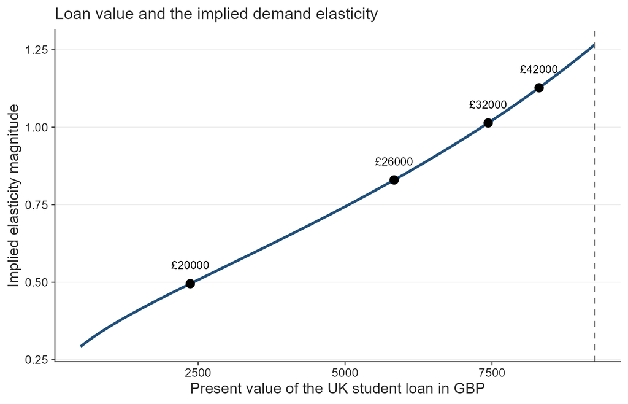

Note: The figure translates the estimated treatment effect into implied demand elasticities under different assumptions about the present value of the UK student loan to EU applicants. Points correspond to elasticity estimates implied by alternative expected graduate earning scenarios. The elasticity here is multiplied by -1 ($\eta_{j}^{'} = - \beta_{j}{/k}_{j}$) for illustrative purposes.

To examine whether structural heterogeneity in demand persists after accounting for this mechanism, we define corrected elasticities as $\eta_j=\beta_j/k_j$. Dividing by heterogeneous $k_j$ removes the portion of elasticity variation induced by differential effective price shocks. After recomputing the elasticities using heterogeneous price changes across the Union, we re-estimate the correlation with GDP per capita. Figure 12 shows how the point estimates change from the fixed $k$ to the loan-corrected $k_j$. The baseline assumes a discount rate of 3%, repayment above the threshold at 9%, nominal wage growth of 2%, and a 30-year repayment horizon.

**Figure 12.** Income gradient in demand elasticity.

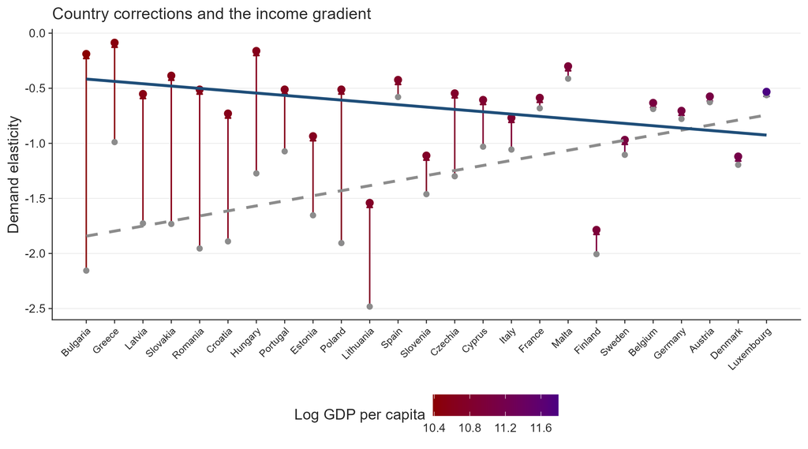

**Note:** The figure compares baseline elasticity estimates with elasticities corrected for heterogeneous loan value across countries. The horizontal axis orders the treated countries from lowest to highest log GDP per capita (PPP) and is labelled with country names, so it is a country-ranking axis and not a continuous GDP scale. The two fitted lines are estimated against this income ordering. Elasticities here are strictly negative as the direct ATT coefficient was divided by $k_{j},$ $\left( \eta_{j}^{'} = \frac{\beta_{j}}{k_{j}}_{\ } \right)$

Figure 12 shows that before correcting for heterogeneous treatment intensity, the income-gradient slope is 1.11 with $p$ < 0.001. Once elasticities are rescaled using country-specific effective price shocks derived from the present value of the income-contingent loan, the slope changes to -0.36 with $p$ 0.236. The difference indicates that a substantial portion of the observed cross-country heterogeneity reflects variation in treatment intensity instead of stable differences in preferences.

From a political perspective, the decline in applications from poorer EU countries reflects the withdrawal of an institution that had quietly equalized opportunity across Europe. The UK’s income-contingent loan system meant that students did not need to arrive with wealth; they needed only the expectation of future effort and earnings. When that system disappeared for EU applicants, the effective cost of studying in the UK rose dramatically for those from poorer economies. What appears in the data as “elastic demand” is therefore better understood as the sudden loss of a mechanism that had allowed talent to travel across borders without the constraint of immediate financial means. In that sense, the Brexit tuition reform did not simply reveal price sensitivity – it exposed how fragile educational mobility can be when the institutions that support it are removed.

## 7.2 What are the real determinants of the corrected elasticity?

**Figure 13.** Alternative correlations between the corrected income elasticity and macroeconomic fundamentals.

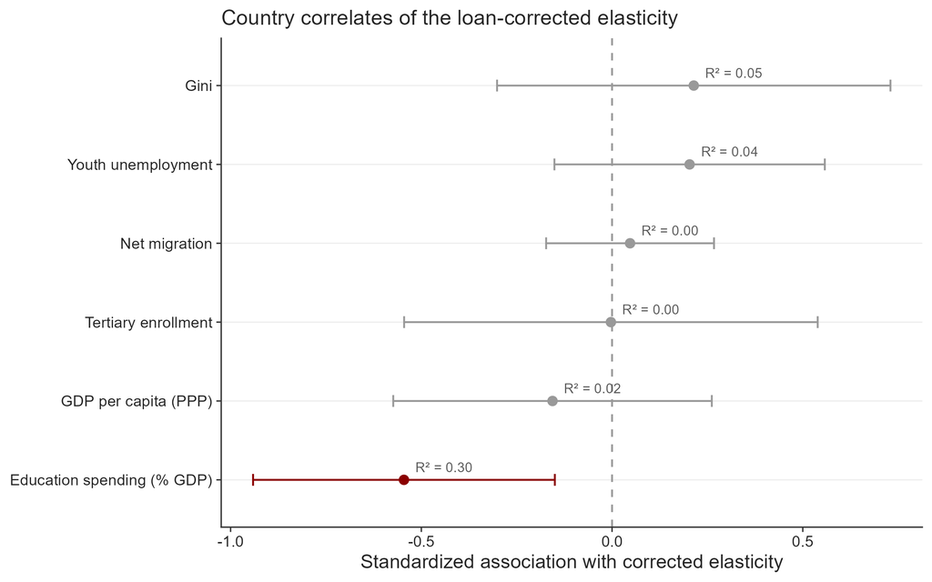

Note: Performed is simple cross-sectional OLS with HC1 robust standard errors. World bank data is from the year 2022. Elasticities are negative values.

Figure 13 shows that most standard macroeconomic indicators explain little the residual variation in the new rescaled elasticities. GDP per capita, tertiary enrollment, net migration, youth unemployment, and inequality all have wide confidence intervals crossing zero and very low explanatory power. This is important because it means that the corrected elasticity is no longer simply a disguised income measure. Once the loan channel is removed, richer countries are not systematically more or less responsive to the tuition shock.

Surprisingly, the only variable that clearly moves the loan-corrected elasticity is education spending as a share of GDP. Its coefficient is negative and statistically significant, with the largest explanatory power among the tested covariates. Substantively, this suggests that countries investing more heavily in education display stronger residual price responsiveness to UK tuition increases. This result also changes the interpretation of post-Brexit heterogeneity.

Before the correction, poorer countries appeared to have the most elastic demand because their observed application declines were largest relative to a uniform nominal fee shock. After correcting for the unequal value of the lost loan, the remaining elasticity is better explained by the structure of educational opportunity, not by national income itself. This result therefore points toward a two-stage mechanism. The raw collapse in applications from lower-income EU countries reflects the removal of an equalizing credit institution. The remaining variation in corrected elasticities reflects substitution possibilities created by national education systems. Brexit first removed the financial bridge that allowed students from poorer economies to access UK higher education. After that correction is made, the strongest determinant of residual responsiveness is whether the origin country already invests enough in education to make exit from the UK market easier.

Ultimately, this is a sovereignty argument. Countries that invest in their own systems give their students exit options, which mechanically makes those students look price-sensitive to UK tuition, not because they're poorer or more fragile but because they're not captive. That inverts the usual read entirely. The "resilient" applicants from poor countries with high measured elasticity-after-correction aren't fragile, they're the ones with somewhere else to go.

# 8 References

Arel-Bundock, V. (2022). WDI: World Development Indicators and other World Bank data (R package version 2.7.8)
$$Computer software$$
. https://CRAN.R-project.org/package=WDI

Arel-Bundock, V., Enevoldsen, N., & Yetman, C. J. (2018). countrycode: An R package to convert country names and country codes. *Journal of Open Source Software*, 3(28), 848. https://doi.org/10.21105/joss.00848

Arkhangelsky, D., Athey, S., Hirshberg, D. A., Imbens, G. W., & Wager, S. (2021). Synthetic difference-in-differences. *American Economic Review, 111*(12), 4088–4118. https://doi.org/10.1257/aer.20190159

Bound, J., Lovenheim, M. F., & Turner, S. (2010). Why have college completion rates declined? *American Economic Journal: Applied Economics*, 2(3), 129–157. https://doi.org/10.1257/app.2.3.129

Bresnahan, T. F. (1982). The oligopoly solution concept is identified. *Economics Letters*, 10(1–2), 87–92. https://doi.org/10.1016/0165-1765(82)90121-5

Brown, R. (2011). After Browne: The new competitive regime for English higher education (CSHE Research & Occasional Paper Series No. CSHE.5.10). Center for Studies in Higher Education, University of California, Berkeley. https://escholarship.org/uc/item/9569q5n5

Calhoun, C. (2017). Populism, nationalism and Brexit. In W. Outhwaite (Ed.), *Brexit: Sociological responses* (pp. 57–76). Anthem Press. Stable link: https://calhoun.faculty.asu.edu/sites/g/files/litvpz3321/files/publications/articles/populism_brexit.pdf

Campbell, R., & Siegel, B. (1967). The Demand for higher education in the United States, 1919–1964. *American Economic Review*, 57(3), 482–494. Stable link: https://www.jstor.org/stable/1812115

Clifton-Sprigg, J., Homburg, I., Huyghe, A., & Vujić, S. (2025). *International student migration: Did Brexit close the door to EU students?* (IZA Discussion Paper No. 18178). IZA Institute of Labor Economics. Stable link: https://www.iza.org/publications/dp/18178/international-student-migration-did-brexit-close-the-door-to-eu-students

Cuibus, M., & Walsh, P. W. (2024). Student migration to the UK. *Migration Observatory Briefing, COMPAS, University of Oxford.* https://www.migrationobservatory.ox.ac.uk

Driscoll, J. C., & Kraay, A. C. (1998). Consistent covariance matrix estimation with spatially dependent panel data. *Review of Economics and Statistics*, 80(4), 549–560. https://doi.org/10.1162/003465398557825

Dwenger, N., Storck, J., & Wrohlich, K. (2012). Do tuition fees affect the mobility of university applicants? Evidence from a natural experiment. *Economics of Education Review*, 31(1), 155–167. https://doi.org/10.1016/j.econedurev.2011.10.004

Eurostat. (2025). *Average full-time adjusted salary per employee*
$$Data set$$
. https://doi.org/10.2908/NAMA_10_FTE

European Central Bank. (2021, July 8). *ECB’s Governing Council approves its new monetary policy strategy*. https://www.ecb.europa.eu/press/pr/date/2021/html/ecb.pr210708~dc78cc4b0d.en.html

Findlay, A., King, R., Stam, A., & Ruiz-Gelices, E. (2006). Ever reluctant Europeans: The changing geographies of UK students studying and working abroad. *European Urban and Regional Studies*, 13(4), 291–318. https://doi.org/10.1177/0969776406065429

Heller, D. E. (1997). Student price response in higher education: An update to Leslie and Brinkman. *Journal of Higher Education*, 68(6), 624–659. Stable link: https://www.jstor.org/stable/2959966

Hemelt, S. W., & Marcotte, D. E. (2011). The impact of tuition increases on enrollment at public colleges and universities. *Educational Evaluation and Policy Analysis*, 33(4), 435–457. https://doi.org/10.3102/0162373711415261

Hoxby, C. M. (1997). *How the changing market structure of U.S. higher education explains college tuition* (NBER Working Paper No. 6323). National Bureau of Economic Research. Stable link: https://www.nber.org/system/files/working_papers/w6323/w6323.pdf

Leslie, D. (2003). Using success to measure quality in British higher education: Which subjects attract the best-qualified students? *Journal of the Royal Statistical Society: Series A (Statistics in Society)*, 166(3), 329–347. https://doi.org/10.1111/1467-985X.00280

Leslie, L. L., & Brinkman, P. T. (1987). Student price response in higher education: The student demand studies. *Journal of Higher Education*, 58(2), 181–204. https://doi.org/10.1080/00221546.1987.11778239

Locke, W., & Marini, G. (2021). The rapid increase in faculty from the European Union in UK higher education institutions and the possible impact of Brexit. In F. Huang & A. R. Welch (Eds.), *International faculty in Asia* (Vol. 21). Springer. https://doi.org/10.1007/978-981-33-4980-3_12

Luthra, R. R. (2020). Mitigating the hostile environment: The role of the workplace in EU migrant experience of Brexit. *Journal of Ethnic and Migration Studies*, 47(1), 190–207. https://doi.org/10.1080/1369183x.2020.1726173

Macdonald, C., & Stratta, E. (2001). From access to widening participation: Responses to the changing population in higher education in the UK. *Journal of Further and Higher Education*, 25(2), 249–258. https://doi.org/10.1080/03098770120050909

Mayhew, K. (2022). Brexit and UK higher education. *Oxford Review of Economic Policy*, 38(1), 179–187. https://doi.org/10.1093/oxrep/grab043

McFadden, D. (1974). Conditional logit analysis of qualitative choice behavior. In P. Zarembka (Ed.), *Frontiers in econometrics* (pp. 105–142). Academic Press. Stable link: https://eml.berkeley.edu/reprints/mcfadden/zarembka.pdf

Neville, R., Rowe, F., & Singleton, A. (2024). Unraveling the Brexit–COVID-19 nexus: Assessing the decline of EU student applications into UK universities. *Data & Policy*, *6*, Article e45. https://doi.org/10.1017/dap.2024.42

Rambachan, A., & Roth, J. (2023). A more credible approach to parallel trends. *Review of Economic Studies*, 90(5), 2555–2591. https://doi.org/10.1093/restud/rdad018

Roth, J. (2022). Pretest with caution: Event-study estimates after testing for parallel trends. *American Economic Review: Insights*, 4(3), 305–322. https://doi.org/10.1257/aeri.20210236

Sá, F. (2014). *The effect of tuition fees on university applications and attendance: Evidence from the UK* (IZA Discussion Paper No. 8364). Institute for the Study of Labor (IZA). https://ftp.iza.org/dp8364.pdf

Savoca, E. (1990). Another look at the demand for higher education: Measuring the price sensitivity of the decision to apply to college. *Economics of Education Review*, 9(2), 123–134. https://doi.org/10.1016/0272-7757(90)90040-C

Solís, A. (2017). Credit access and college enrollment. *Journal of Political Economy*, 125(2), 562–622. https://doi.org/10.1086/690829

UCAS. (2022). *UCAS undergraduate sector-level end of cycle data resources 2021*
$$Data set$$
. https://www.ucas.com/data-and-analysis/undergraduate-statistics-and-reports/ucas-undergraduate-sector-level-end-of-cycle-data-resources-2021

UK Government. (n.d.-a). *Repaying your student loan: What you pay.* GOV.UK. https://www.gov.uk/repaying-your-student-loan/what-you-pay

UK Government. (n.d.-b). *When your student loan gets written off or cancelled.* GOV.UK. https://www.gov.uk/repaying-your-student-loan/when-your-student-loan-gets-written-off

UK Government. (n.d.-c). *How interest is calculated (Plan 2).* GOV.UK. https://www.gov.uk/guidance/how-interest-is-calculated-plan-2

World Bank. (2025). *World Development Indicators*
$$Data set$$
. https://databank.worldbank.org/source/world-development-indicators